# Visualizing Election Prediction

Saeid Abolfazli

June 3, 2016

# Load data

```r
library(lubripack)
lubripack("ggplot2", "maps","ggmap")
```

```
##
##  # maps v3.1: updated 'world': all lakes moved to separate new #
##  # 'lakes' database. Type '?world' or 'news(package="maps")'.  #
```

```
##
## Bellow Packages Successfully Installed:
##
## ggplot2    maps   ggmap
##    TRUE    TRUE    TRUE
```

# Description

In the recitation from Unit 3, we used logistic regression on polling data in order to construct US presidential election predictions. We separated our data into a training set, containing data from 2004 and 2008 polls, and a test set, containing the data from 2012 polls. We then proceeded to develop a logistic regression model to forecast the 2012 US presidential election.

In this homework problem, we’ll revisit our logistic regression model from Unit 3, and learn how to plot the output on a map of the United States. Unlike what we did in the Crime lecture, this time we’ll be plotting predictions rather than data!

First, load the ggplot2, maps, and ggmap packages using the library function. All three packages should be installed on your computer from lecture, but if not, you may need to install them too using the install.packages function.

Then, load the US map and save it to the variable statesMap, like we did during the Crime lecture:

```r
statesMap <- map_data("state")
table(statesMap$group)
```

```
##
##    1    2    3    4    5    6    7    8    9   10   11   12   13   14   15
##  202  149  312  516   79   91   94   10  872  381  233  329  257  256  113
##   16   17   18   19   20   21   22   23   24   25   26   27   28   29   30
##  397  650  399  566   36  220   30  460  370  373  382  315  238  208   70
##   31   32   33   34   35   36   37   38   39   40   41   42   43   44   45
##  125  205   78   16  290   21  168   37  733   12  105  238  284  236  172
##   46   47   48   49   50   51   52   53   54   55   56   57   58   59   60
##   66  304  166  289 1088   59  129   96   15  623   17   17   19   44  448
##   61   62   63
##  373  388   68
```

The maps package contains other built-in maps, including a US county map, a world map, and maps for France and Italy.

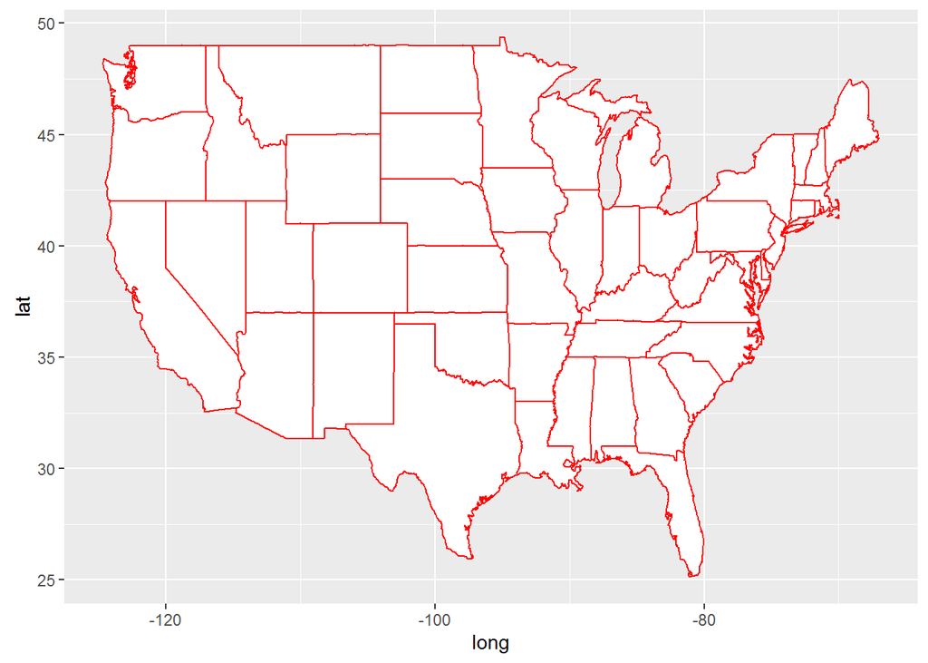

```r
ggplot(statesMap, aes(x = long, y = lat, group = group)) + geom_polygon(fill = "white", color = "red")
```

# Problem 2.1 - Coloring the States by Predictions

Now, let’s color the map of the US according to our 2012 US presidential election predictions from the Unit 3 Recitation. We’ll rebuild the model here, using the dataset PollingImputed.csv. Be sure to use this file so that you don’t have to redo the imputation to fill in the missing values, like we did in the Unit 3 Recitation.

Load the data using the read.csv function, and call it “polling”. Then split the data using the subset function into a training set called “Train” that has observations from 2004 and 2008, and a testing set called “Test” that has observations from 2012.

```r
file <- file.path("data","Pollingimputed.csv")
polling <- read.csv(file)
train <- subset(polling, Year == 2004 | Year == 2008)
test <- subset(polling, Year == 2012)
```

Note that we only have 45 states in our testing set, since we are missing observations for Alaska, Delaware, Alabama, Wyoming, and Vermont, so these states will not appear colored in our map.

Then, create a logistic regression model and make predictions on the test set using the following commands:

```r
mod2 <- glm(Republican~SurveyUSA+DiffCount, data=train, family="binomial")
TestPrediction <- predict(mod2, newdata=test, type="response")
```

TestPrediction gives the predicted probabilities for each state, but let’s also create a vector of Republican/Democrat predictions by using the following command:

```r
TestPredictionBinary <- as.numeric(TestPrediction > 0.5)
```

Now, put the predictions and state labels in a data.frame so that we can use ggplot:

```r
predictionDataFrame = data.frame(TestPrediction, TestPredictionBinary, test$State)
```

To make sure everything went smoothly, answer the following questions.

For how many states is our binary prediction 1 (for 2012), corresponding to Republican?

```r
table(predictionDataFrame$TestPredictionBinary)
```

```
##
##  0  1
## 23 22
```

What is the average predicted probability of our model (on the Test set, for 2012)?

```r
mean(predictionDataFrame$TestPrediction)
```

```
## [1] 0.4852626
```

# Problem 2.2 - Coloring the States by Predictions

Now, we need to merge “predictionDataFrame” with the map data “statesMap”, like we did in lecture. Before doing so, we need to convert the Test.State variable to lowercase, so that it matches the region variable in statesMap. Do this by typing the following in your R console:

```r
predictionDataFrame$region = tolower(predictionDataFrame$test.State)
```

Now, merge the two data frames using the following command:

```r
predictionMap = merge(statesMap, predictionDataFrame, by = "region")
```

Lastly, we need to make sure the observations are in order so that the map is drawn properly, by typing the following:

```r
predictionMap = predictionMap[order(predictionMap$order),]
```

## How many observations are there in predictionMap?

```r
nrow(predictionMap)
```

```
## [1] 15034
```

```r
nrow(statesMap)
```

```
## [1] 15537
```

# How many observations are there in statesMap?

15537

# Problem 2.3 - Coloring the States by Predictions

When we merged the data in the previous problem, it caused the number of observations to change. Why? Check out the help page for merge by typing ?merge to help you answer this question.

**Aswer:** Because we only make predictions for 45 states, we no longer have observations for some of the states. These observations were removed in the merging process.

See below

```r
nrow(predictionDataFrame)##45
```

```
## [1] 45
```

```r
nrow(statesMap)#15537
```

```
## [1] 15537
```

```r
nrow(predictionMap) ##15034
```

```
## [1] 15034
```

```r
15537 - 15034
```

```
## [1] 503
```

```r
table(statesMap$region)
```

```
##
##              alabama              arizona             arkansas
##                  202                  149                  312
##           california             colorado          connecticut
##                  516                   79                   91
##             delaware district of columbia              florida
##                   94                   10                  872
##              georgia                idaho             illinois
##                  381                  233                  329
##              indiana                 iowa               kansas
##                  257                  256                  113
##             kentucky            louisiana                maine
##                  397                  650                  399
##             maryland        massachusetts             michigan
##                  566                  286                  830
##            minnesota          mississippi             missouri
##                  373                  382                  315
##              montana             nebraska               nevada
##                  238                  208                   70
##        new hampshire           new jersey           new mexico
##                  125                  205                   78
##             new york       north carolina         north dakota
##                  495                  782                  105
##                 ohio             oklahoma               oregon
##                  238                  284                  236
##         pennsylvania         rhode island       south carolina
##                  172                   66                  304
##         south dakota            tennessee                texas
##                  166                  289                 1088
##                 utah              vermont             virginia
##                   59                  129                  734
##           washington        west virginia            wisconsin
##                  545                  373                  388
##              wyoming
##                   68
```

```r
0+94+202+68+129
```

```
## [1] 493
```

```r
table(predictionMap$region)
```

```
##
##        arizona       arkansas     california       colorado    connecticut
##            149            312            516             79             91
##        florida        georgia          idaho       illinois        indiana
##            872            381            233            329            257
##           iowa         kansas       kentucky      louisiana          maine
##            256            113            397            650            399
##       maryland  massachusetts       michigan      minnesota    mississippi
##            566            286            830            373            382
##       missouri        montana       nebraska         nevada  new hampshire
##            315            238            208             70            125
##     new jersey     new mexico       new york north carolina   north dakota
##            205             78            495            782            105
##           ohio       oklahoma         oregon   pennsylvania   rhode island
##            238            284            236            172             66
## south carolina   south dakota      tennessee          texas           utah
##            304            166            289           1088             59
##       virginia     washington  west virginia      wisconsin
##            734            545            373            388
```

# Problem 2.4 - Coloring the States by Predictions

Now we are ready to color the US map with our predictions! You can color the states according to our binary predictions by typing the following in your R console:

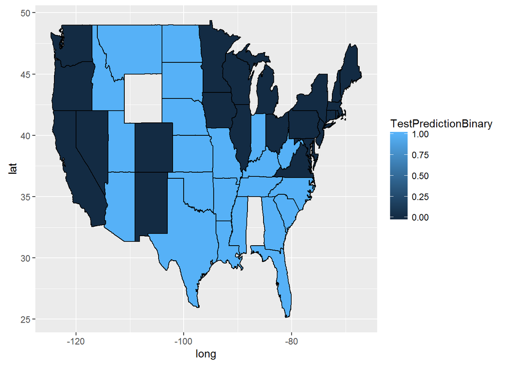

```r
ggplot(predictionMap, aes(x = long, y = lat, group = group, fill = TestPredictionBinary)) + geom_polygon(color = "black")
```

The states appear light blue and dark blue in this map. Which color represents a Republican prediction?

**Answer:** Light blue

# Problem 2.5 - Coloring the States by Predictions

We see that the legend displays a blue gradient for outcomes between 0 and 1. However, when plotting the binary predictions there are only two possible outcomes: 0 or 1. Let’s replot the map with discrete outcomes. We can also change the color scheme to blue and red, to match the blue color associated with the Democratic Party in the US and the red color associated with the Republican Party in the US. This can be done with the following command:

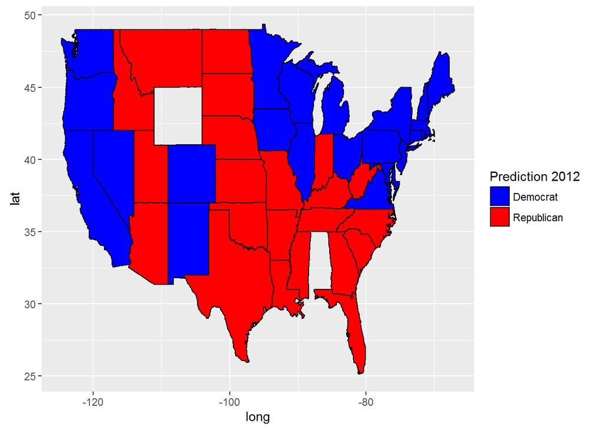

```r
ggplot(predictionMap, aes(x = long, y = lat, group = group, fill = TestPredictionBinary))+ geom_polygon(color = "black") + scale_fill_gradient(low = "blue", high = "red", guide = "legend", breaks= c(0,1), labels = c("Democrat", "Republican"), name = "Prediction 2012")
```

Alternatively, we could plot the probabilities instead of the binary predictions. Change the plot command above to instead color the states by the variable TestPrediction. You should see a gradient of colors ranging from red to blue. Do the colors of the states in the map for TestPrediction look different from the colors of the states in the map with TestPredictionBinary? Why or why not?

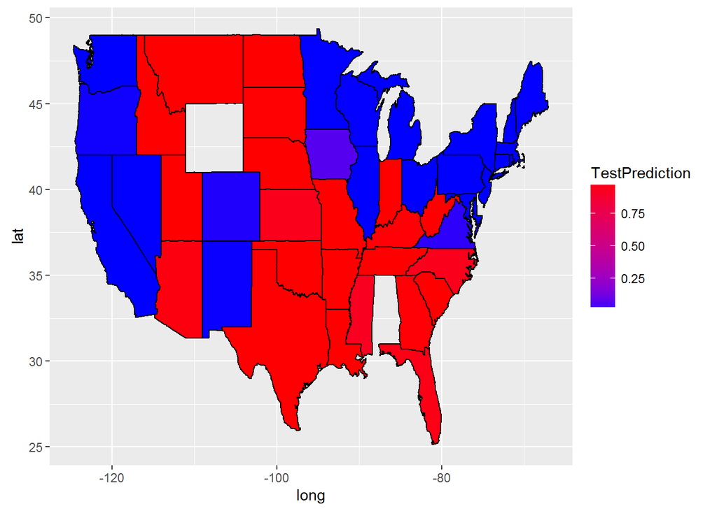

```r
ggplot(predictionMap, aes(x=long, y=lat, group = group , fill=TestPrediction)) + geom_polygon(color = "black") +scale_fill_gradient(low="blue",high="red")
```

NOTE: If you have a hard time seeing the red/blue gradient, feel free to change the color scheme, by changing the arguments low = “blue” and high = “red” to colors of your choice (to see all of the color options in R, type colors() in your R console). You can even change it to a gray scale, by changing the low and high colors to “gray” and “black”.

**Answer:** The two maps look very similar. This is because most of our predicted probabilities are close to 0 or close to 1.

# Problem 3.1 - Understanding the Predictions

In the 2012 election, the state of Florida ended up being a very close race. It was ultimately won by the Democratic party. Did we predict this state correctly or incorrectly? To see the names and locations of the different states, take a look at the World Atlas map here.

```r
table(predictionMap$region, predictionMap$TestPredictionBinary)
```

```
##
##                     0    1
##   arizona           0  149
##   arkansas          0  312
##   california      516    0
##   colorado         79    0
##   connecticut      91    0
##   florida           0  872
##   georgia           0  381
##   idaho             0  233
##   illinois        329    0
##   indiana           0  257
##   iowa            256    0
##   kansas            0  113
##   kentucky          0  397
##   louisiana         0  650
##   maine           399    0
##   maryland        566    0
##   massachusetts   286    0
##   michigan        830    0
##   minnesota       373    0
##   mississippi       0  382
##   missouri          0  315
##   montana           0  238
##   nebraska          0  208
##   nevada           70    0
##   new hampshire   125    0
##   new jersey      205    0
##   new mexico       78    0
##   new york        495    0
##   north carolina    0  782
##   north dakota      0  105
##   ohio            238    0
##   oklahoma          0  284
##   oregon          236    0
##   pennsylvania    172    0
##   rhode island     66    0
##   south carolina    0  304
##   south dakota      0  166
##   tennessee         0  289
##   texas             0 1088
##   utah              0   59
##   virginia        734    0
##   washington      545    0
##   west virginia     0  373
##   wisconsin       388    0
```

**Answer:** We incorrectly predicted this state by predicting that it would be won by the Republican party.

# Problem 3.2 - Understanding the Predictions

What was our predicted probability for the state of Florida?

```r
0.96
```

```
## [1] 0.96
```

What does this imply?

**Answer:** Our prediction model did not do a very good job of correctly predicting the state of Florida, and we were very confident in our incorrect prediction.

# PROBLEM 4 - PARAMETER SETTINGS

In this part, we’ll explore what the different parameter settings of geom_polygon do. Throughout the problem, use the help page for geom_polygon, which can be accessed by ?geom_polygon. To see more information about a certain parameter, just type a question mark and then the parameter name to get the help page for that parameter. Experiment with different parameter settings to try and replicate the plots!

We’ll be asking questions about the following three plots:

Plot (1)

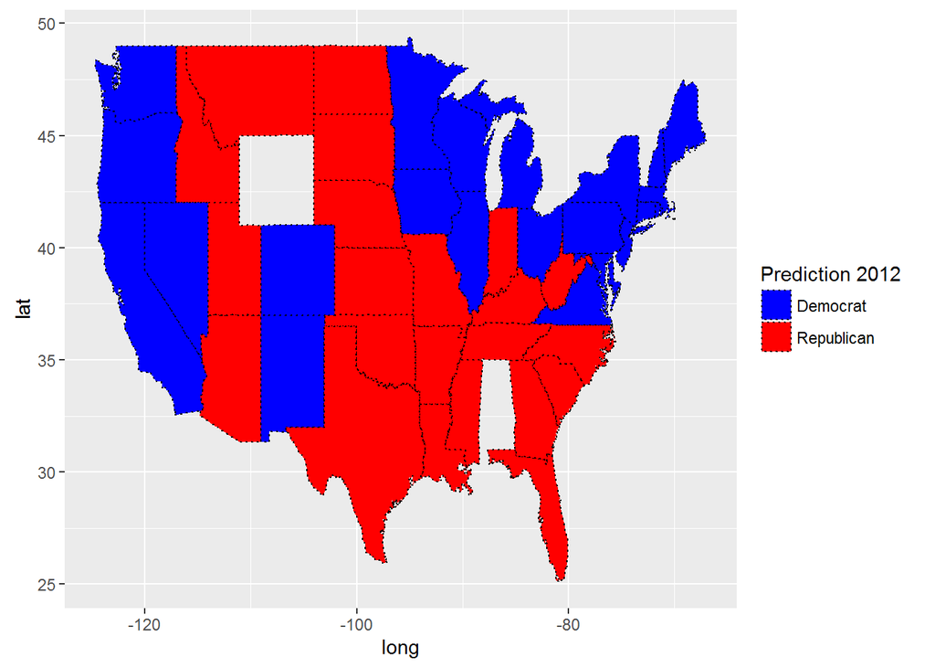

Plot (2)

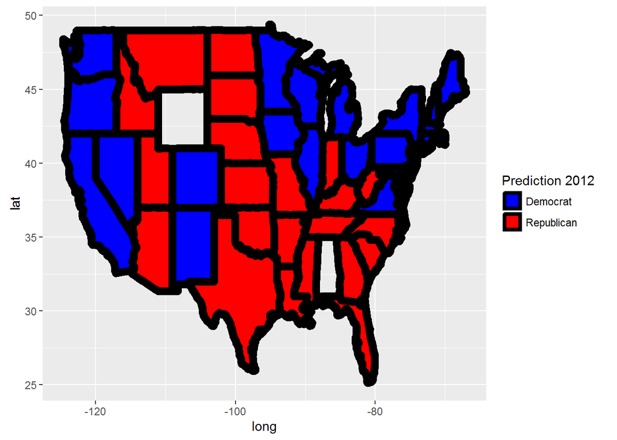

Plot (3)

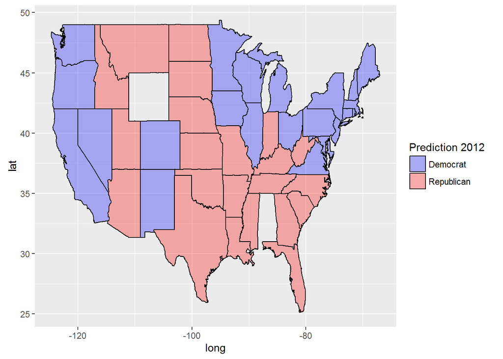

## Problem 4.1 - Parameter Settings

Plots (1) and (2) were created by setting different parameters of geom_polygon to the value 3.

What is the name of the parameter we set to have value 3 to create plot (1)?

**Answer:** linetype

What is the name of the parameter we set to have value 3 to create plot (2)?

**Answer:** size

## Problem 4.2 - Parameter Settings

Plot (3) was created by changing the value of a different geom_polygon parameter to have value 0.3. Which parameter did we use?

**Answer:** alpha